# Predykcja zachorowań na nowotwory piersi w Polsce

Dominik Ambroziak, Michał Jaworski, Iwona Majewska, Krzysztof Smutek

31 maja 2016

# Wstęp

Cel, który postawiliśmy sobie w grugiej fazie projektu to predykcja liczby kobiet chorych na nowotwory piersi (C50_D05 według klasyfikacji ICD-10) w roku 2013 w podziale na powiaty na 100 tys. kobiet mieszkających w powiecie. Zbudowany model uwzględniał:

- podział powiatów na grodzkie i ziemskie, kodowane odpowiednio jako 1 i 0.
- liczbę chorych kobiet na 100 tys. kobiet mieszkających w powiecie w poszczególnych stadiach nowotworu dla dwóch poprzednich lat
- liczbę nowych przypadków zachorowań na 100 tys. kobiet mieszkających w powiecie dla dwóch poprzednich lat.

Na tej podstawie prognozowana była liczba chorych na 100 tys. mieszkańców w następnym roku.

Model został stworzony i przetestowany na podstawie danych z lat 2010 - 2012, gdzie dane z roku 2010 i 2011 modelowały zachorowania w roku 2012. Następnie dane z lat 2011 i 2012 zostały użyte do predykcji zachorowań w roku 2013.

Aby wobrać model najlepiej stosujący się do naszych danych, przetestowaliśmy różne podejścia:

- pełny model liniowy
- model liniowy z wyborem parametrów przy pomocy kryterium AIC
- model liniowy z wyborem parametrów przy pomocy kryterium BIC
- model ridge regression (α = 0), lasso (α = 1), half (α = 1/2)
- principal component regression wełnowymiarowe i z trzema komponentami.

# Ocena jakości modeli

Dla wymienionych powyżej modeli obliczony został błąd średniokwadratowy. W tym celu zbiór danych został podzielony na dwa podzbiory - treningowy i testowy. Podzbiór treningowy posłużył do dopasowania modelu, a testowy do obliczenia błędu średniokwadratowego. Procedura została powtórzona 100 razy dla każdej metody. Otrzymane wyniki są przedstawione na wykresie.

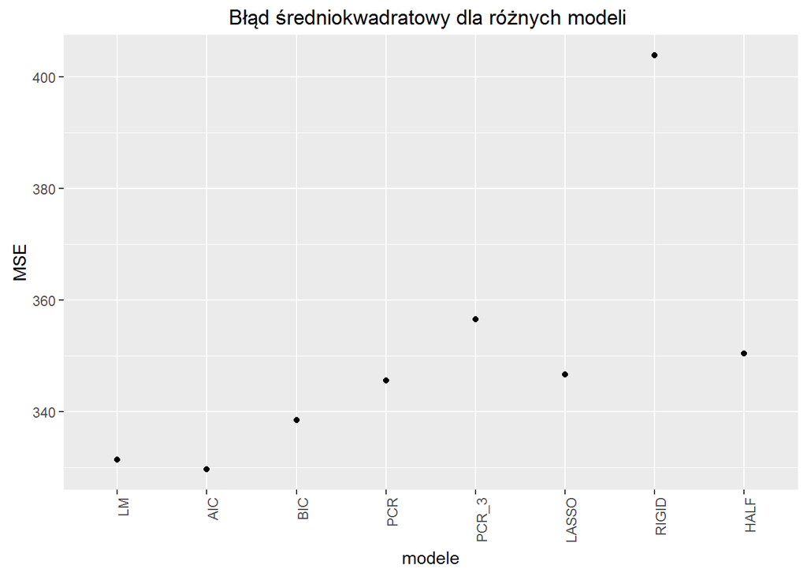

Najmniejszy błąd średniokwadratowy wykazuje model z minimalnym kryterium AIC.

Aby ocenić jakości modeli, obliczone zostały odchylenia standardowe jako pierwiastki z MSE. Zestawiono je ze średnimi liczbami zachorowań na 100 tys. kobiet. Wyniki przedstawia poniższa tabela.

```
##   model  Średnia     RMSE
## 1   AIC 89.07077 18.15680
## 2    LM 89.12123 18.20306
## 3   BIC 88.95094 18.39807
## 4   PCR 89.15297 18.58862
## 5 LASSO 88.89058 18.61803
## 6  HALF 88.91313 18.71937
## 7 RIGID 88.90764 20.09524
```

## Optymalny model według kryterium AIC - parametry

Przyjrzyjmy się dokładniej paramertom modelu o najmniejszym błędzie średniokwadratowym.

```
##
## Call:
## lm(formula = dane$chore ~ new + Stage12 + Stage22 + Stage32 +
##     Stage42 + miasto, data = dane, model = TRUE)
##
## Residuals:
##     Min      1Q  Median      3Q     Max
## -41.600 -12.788  -1.053  11.287  51.213
##
## Coefficients:
##             Estimate Std. Error t value Pr(>|t|)
## (Intercept) 45.29370    4.30030  10.533  < 2e-16 ***
## new          0.23409    0.04837   4.839 1.91e-06 ***
## Stage12      0.37522    0.14874   2.523  0.01206 *
## Stage22      0.13778    0.06986   1.972  0.04931 *
## Stage32      0.24837    0.09629   2.580  0.01028 *
## Stage42      0.37576    0.13841   2.715  0.00694 **
## miasto      14.50132    2.85293   5.083 5.90e-07 ***
## ---
## Signif. codes:  0 '***' 0.001 '**' 0.01 '*' 0.05 '.' 0.1 ' ' 1
##
## Residual standard error: 17.88 on 372 degrees of freedom
## Multiple R-squared:  0.3701, Adjusted R-squared:  0.3599
## F-statistic: 36.43 on 6 and 372 DF,  p-value: < 2.2e-16
```

W powyższym modelu uwzględnione zostały: liczba nowych przypadków zachorowań w roku 2010, liczby chorych w poszczególnych stadiach w 2011 roku i informacja o rodzaju powiatu.

W dalszej części prezentacji do obliczeń predykcji dla roku 2013 zostanie użyty model AIC.

# Przedstawienie wyników predykcji

Przewidywane liczby zachorowań na 100 tys. kobiet dla poszczególnych powiatów przedstawia poniższy kartogram. Kolory na nim są dobrane tak, aby biały sygnalizował powiaty o liczbie zachorowań równej średniej, czerwony zachorowania powyżej średniej i niebieski - poniżej średniej.

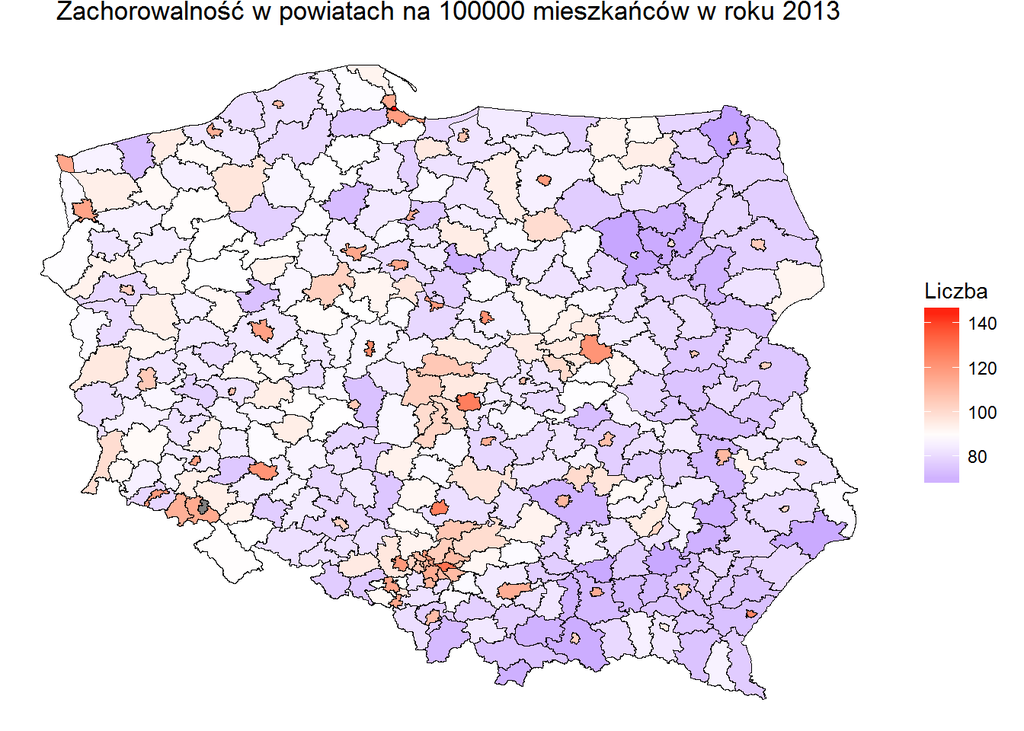

W poprzedniej fazie projektu wykazaliśmy, że średnia zachorowalność w miastach na prawach powiatu jest wyższa niż w powiatach ziemskich. Poniższy wykres pokazuje, jak kształtuje się ta zależność w poszczególnych latach.

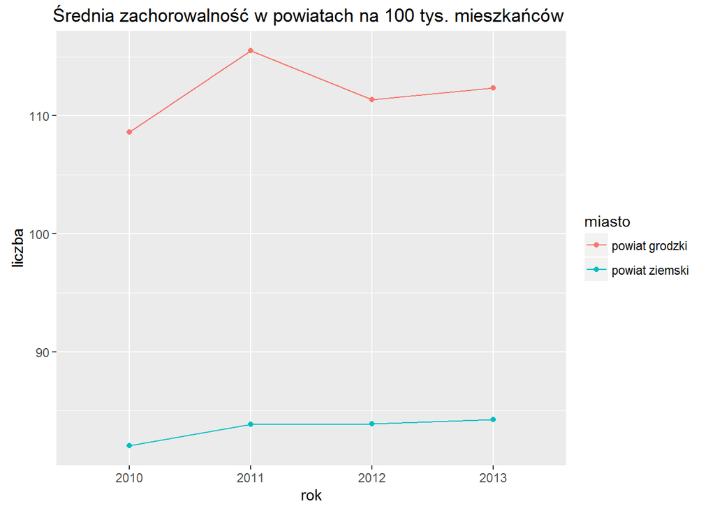

Zachorowalność w powiatach ziemskich wykazuje tendencję rosnącą, zaś w powiatach grodzkich występuje maksimum dla 2011 roku.

Przyjrzeliśmy się, jaki procent zachorowań odpowiada powiatom ziemskim i grodzkim w poszczególnych latach.

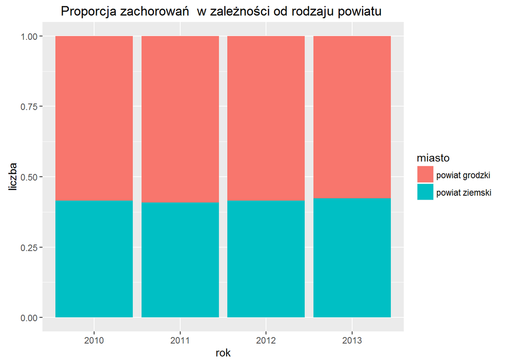

Różnica w zachorowaniach pomiędzy powiatami ziemskimi i grodzkimi nieznacznie zmniejsza się, z wyjątkiem zależności między rokiem 2010 i 2011. Prognozowane jest dalsze zmniejszanie się, jednak odbywa się ono bardzo powoli.

Kolejny wykres przedstawia liczbę chorych na 100 tys. mieszkańców w podziale na województwa.

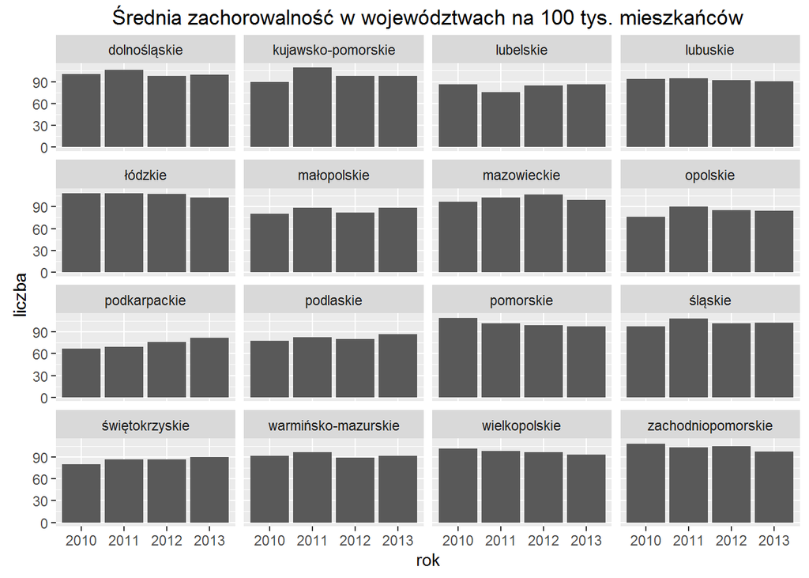

Różne województwa wykazują różne zależności zachorowań od roku. W województwach: lubuskim, łódzkim, pomorskim, wielkopolskim i zachodniopomorskim liczba chorych kobiet maleje w latach 2010 - 2013. W województwach podkarpackim, podlaskim i świętokrzyskim zachorowalność rośnie. Być może wskazuje to na zwiększającą się efektywność w wykrywaniu nowotworów piersi u kobiet w województwach o niższym poziomie rozwoju. Jednak należy pamiętać, że te wyniki bazują na danych zaledwie z trzech lat.

# Podsumowanie

Z wypróbowanych modeli stworzonych do przewidywania liczby kobiet chorych na nowotwory piersi w roku 2013 najlepszy pod kątem minimalizacji błędu średniokwadratowego okazał się model minimalizujący parametr AIC. Jednak odchylenia standardowe we wszystkich modelach były stosunkowo duże (około 18 przypadków na 100 tys. kobiet, przy średniej około 90). Oznacza to, że przyjęty model wymaga udoskonaleń. Czynniki, które można spróbować uwzględnić w kolejnej fazie projektu:

- wskaźnik urbanizacji dla powiatów (zamiast binarnego rozóżnienia na powiaty grodzkie lub ziemskie)
- struktura wiekowa w powiatach lub województwach.

Inspiracje, jak udoskonalić model daje też analiza zachorowalności dla województw. Ponieważ zachorowalność rośnie w województwach tak zwanej Polski B, o niższym poziomie rozwoju, możnaby też spróbować włączyć czynniki związane z rozwojem województw (na przykład uprzemysłowienie).

# Załącznik

## Regresja logistyczna

```
##
## Call:  glm(formula = Chory ~ Płeć + Wiek + Powiat, family = binomial(),
##     data = logit)
##
## Coefficients:
## (Intercept)         Płeć         Wiek       Powiat
##    -12.3027       3.5285       2.4204       0.2651
##
## Degrees of Freedom: 999995 Total (i.e. Null);  999992 Residual
## Null Deviance:       8646
## Residual Deviance: 7615  AIC: 7623
```

```
##
## Call:
## glm(formula = Chory ~ Płeć + Wiek + Powiat, family = binomial(),
##     data = logit)
##
## Deviance Residuals:
##     Min       1Q   Median       3Q      Max
## -0.0673  -0.0201  -0.0176  -0.0034   4.4457
##
## Coefficients:
##              Estimate Std. Error z value Pr(>|z|)
## (Intercept) -12.30270    0.31852 -38.624  < 2e-16 ***
## Płeć          3.52854    0.29222  12.075  < 2e-16 ***
## Wiek          2.42044    0.14911  16.233  < 2e-16 ***
## Powiat        0.26512    0.09059   2.926  0.00343 **
## ---
## Signif. codes:  0 '***' 0.001 '**' 0.01 '*' 0.05 '.' 0.1 ' ' 1
##
## (Dispersion parameter for binomial family taken to be 1)
##
##     Null deviance: 8646.2  on 999995  degrees of freedom
## Residual deviance: 7614.6  on 999992  degrees of freedom
## AIC: 7622.6
##
## Number of Fisher Scoring iterations: 13
```

```
##     Płeć     Wiek   Powiat
## 1.000204 1.000815 1.000731
```

## Pełny model liniowy - parametry

```
##
## Call:
## lm(formula = dane$chore ~ ., data = dane, model = TRUE)
##
## Residuals:
##     Min      1Q  Median      3Q     Max
## -42.903 -12.492  -0.554  11.567  50.935
##
## Coefficients:
##             Estimate Std. Error t value Pr(>|t|)
## (Intercept) 45.63538    4.42708  10.308  < 2e-16 ***
## Stage1      -0.22409    0.86848  -0.258    0.797
## Stage2      -0.28105    0.85451  -0.329    0.742
## Stage3      -0.32103    0.85491  -0.376    0.707
## Stage4      -0.01765    0.84816  -0.021    0.983
## new          0.47907    0.84658   0.566    0.572
## Stage12      0.89166    0.95733   0.931    0.352
## Stage22      0.70550    0.93898   0.751    0.453
## Stage32      0.81830    0.93707   0.873    0.383
## Stage42      0.87086    0.94611   0.920    0.358
## new2        -0.55395    0.93497  -0.592    0.554
## miasto      15.03837    2.90248   5.181 3.65e-07 ***
## ---
## Signif. codes:  0 '***' 0.001 '**' 0.01 '*' 0.05 '.' 0.1 ' ' 1
##
## Residual standard error: 17.92 on 367 degrees of freedom
## Multiple R-squared:  0.376,  Adjusted R-squared:  0.3573
## F-statistic: 20.11 on 11 and 367 DF,  p-value: < 2.2e-16
```

## Optymalny model według krytrium BIC - parametry

```
##
## Call:
## lm(formula = dane$chore ~ new + Stage32 + Stage42 + miasto, data = dane,
##     model = TRUE)
##
## Residuals:
##     Min      1Q  Median      3Q     Max
## -43.030 -13.115  -1.114  11.968  52.917
##
## Coefficients:
##             Estimate Std. Error t value Pr(>|t|)
## (Intercept) 47.78756    4.19034  11.404  < 2e-16 ***
## new          0.29074    0.04485   6.483 2.84e-10 ***
## Stage32      0.27827    0.09670   2.878  0.00424 **
## Stage42      0.44414    0.13802   3.218  0.00140 **
## miasto      16.02744    2.78613   5.753 1.83e-08 ***
## ---
## Signif. codes:  0 '***' 0.001 '**' 0.01 '*' 0.05 '.' 0.1 ' ' 1
##
## Residual standard error: 18.07 on 374 degrees of freedom
## Multiple R-squared:  0.3535, Adjusted R-squared:  0.3466
## F-statistic: 51.12 on 4 and 374 DF,  p-value: < 2.2e-16
```